# Project 4 - Evaluate Oregon Contributions

## Evaluate data by Candidate

Looking to see any patterns, trends, or anomolies that arise

```
## [1] 6093
```

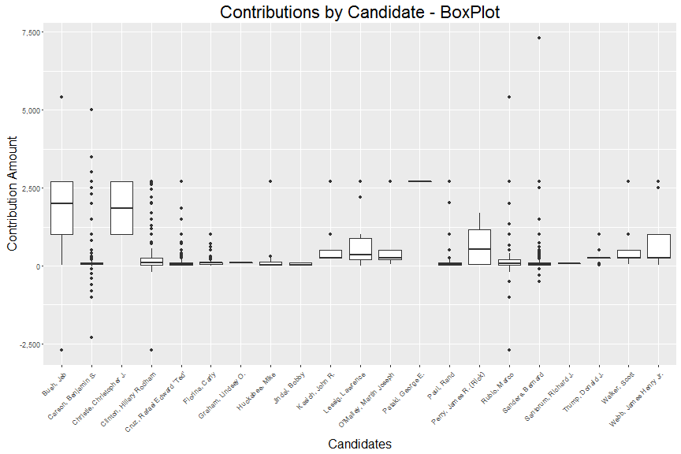

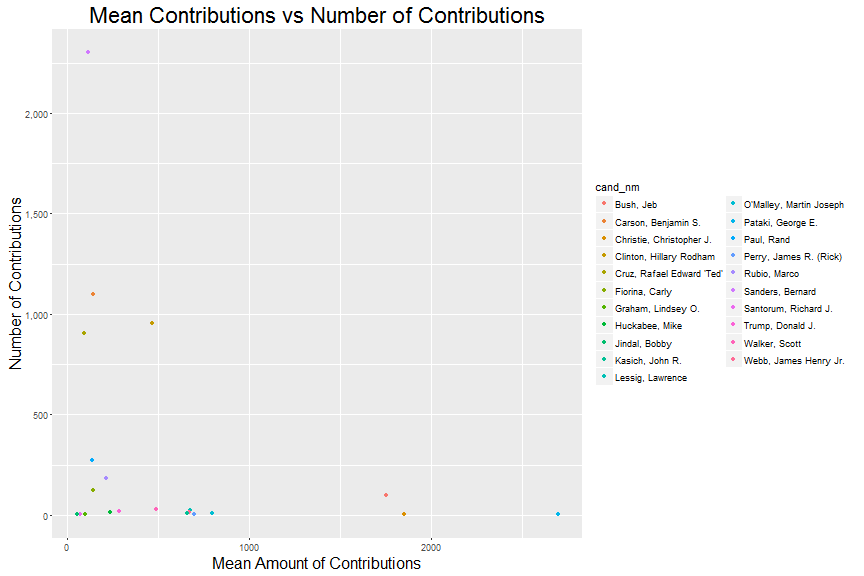

There appears to be a relationship between contribution size and number of contributors but it is not linear. Also with so many candidates it is hard.

The highest number of contributions is 2305.  
The largest Mean Contribution is 2700.

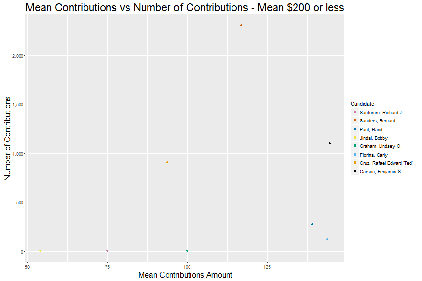

## Total contributions by candidate

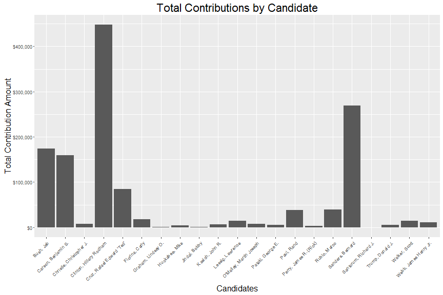

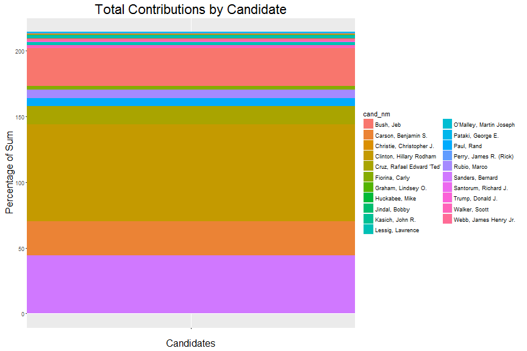

[figure not shown]

```
## Source: local data frame [5 x 7]
##
##                     cand_nm cand_mean cand_median cand_sum cand_sum_pct
##                      (fctr)     (dbl)       (dbl)    (dbl)        (dbl)
## 1          Sanders, Bernard 116.91878          50 269497.8    44.230720
## 2       Carson, Benjamin S. 144.55158          60 159006.7    26.096626
## 3   Clinton, Hillary Rodham 467.85541         100 447737.6    73.483937
## 4 Cruz, Rafael Edward 'Ted'  93.73594          50  85018.5    13.953471
## 5                Paul, Rand 139.05646          50  37684.3     6.184851
## Variables not shown: n (int), cand_n_pct (dbl)
```

## Evaluate by Political Party

Looking to see any patterns, trends, or anomolies that arise

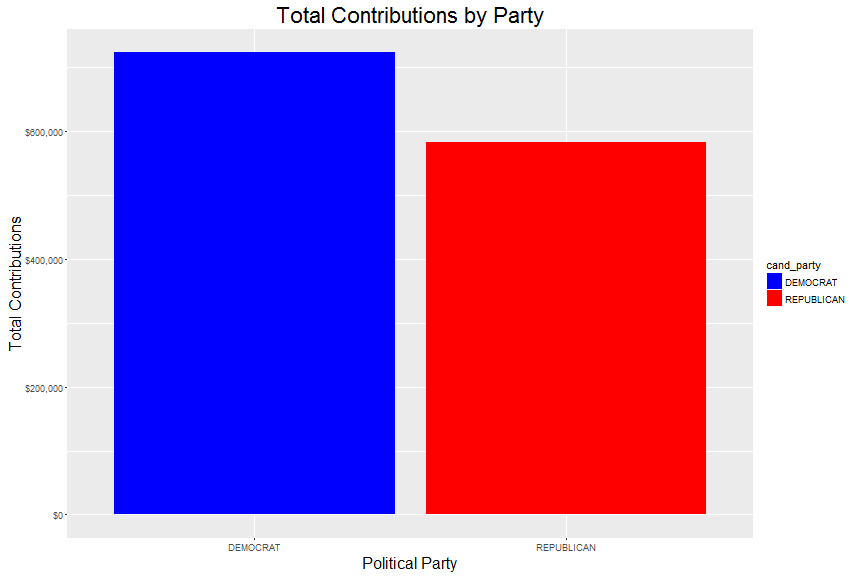

Total for Democrat donations: 7.2443641 × 10<sup>5</sup>

Total for Republican donations: 5.8299452 × 10<sup>5</sup>

## Evaluate by Candidate Gender

Looking to see any patterns, trends, or anomolies that arise

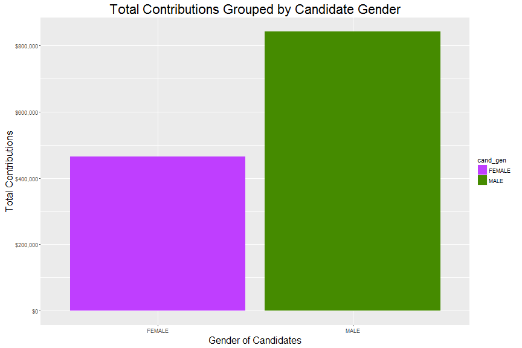

Total for Donations for Female Candidates: 4.6541163 × 10<sup>5</sup>

Total for Donations for Male Candidates: 8.420193 × 10<sup>5</sup>

## Evaluate zip code

Looking to see any patterns, trends, or anomolies that arise

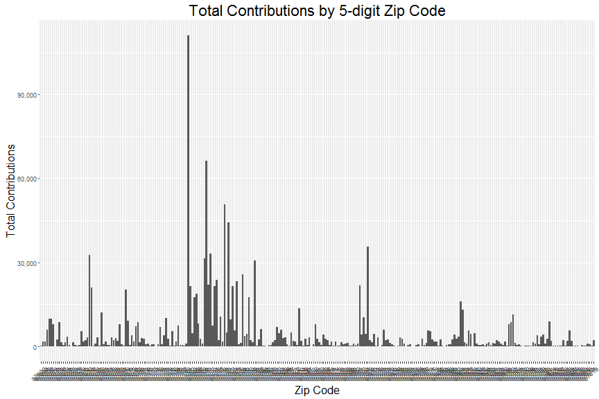

Too many for this to be very meaningful. Let's see what the top 5 are and graph just those.

Mean Contribution by zip-code: 229.3979295

```
## Source: local data frame [5 x 5]
##
##    zip5  zip_mean zip_median   zip_sum     n
##   (chr)     (dbl)      (dbl)     (dbl) (int)
## 1 97201 1001.3011        400 111144.42   111
## 2 97210 1163.7288        700  66332.54    57
## 3 97219  464.1437        100  50591.66   109
## 4 97221  789.6346        100  44219.54    56
## 5 97405  201.7743         50  35512.28   176
```

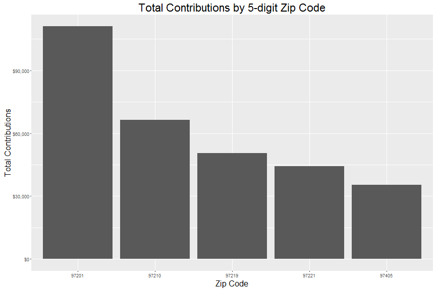

This looks better, at least it is readable on the y-axis

Mean: 724.1164968

This is quite a bit higher than the mean using all zip codes

## Evaluate Candidate and Party through time

Looking to see any patterns, trends, or anomolies that arise

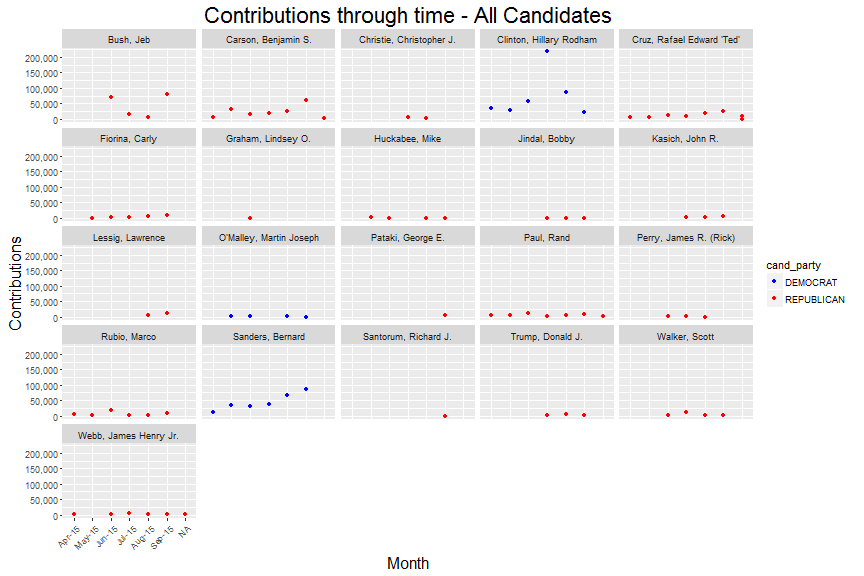

We can see that Clinton has a high point that is throwing off the graph for all other candidates.

## Evaluate Democrats only

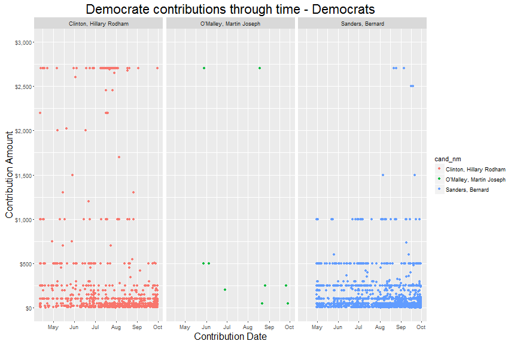

This chart shows that people prefer to contribute at round numbers like $500, or $1000. you can also see that there are a number at $2700. Lots of noise below $250 so digging deeper.

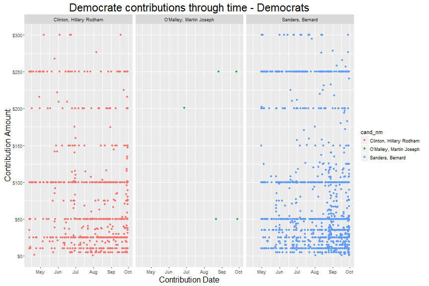

Still see distinct lines at round numbers, which isn't really all that surprising.

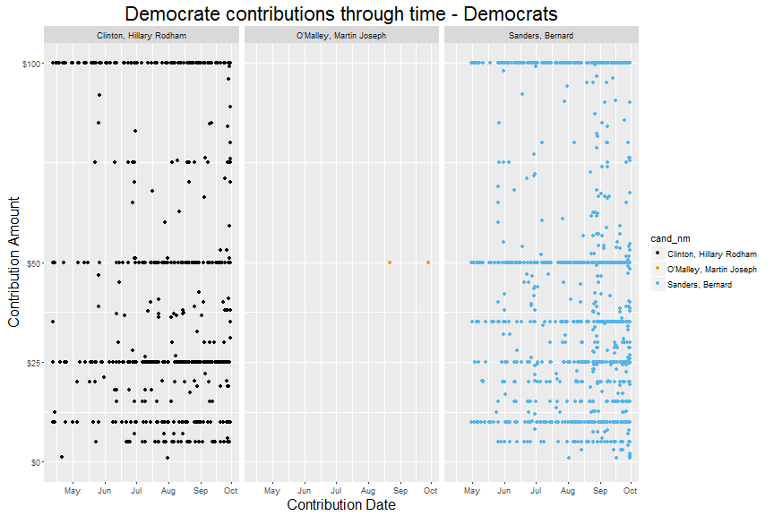

Noticeably more donation for Sanders at this level, though Clinton's donations go back slightly further in time.

## Evaluate Republicans Only

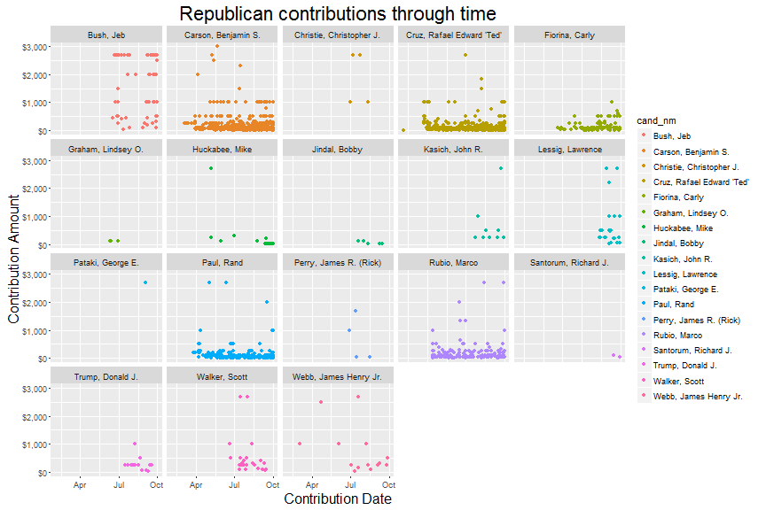

You see the same pattern of round value contributions in the republicans too. Same visibilty issues on the low ranges, lets break this out more too.

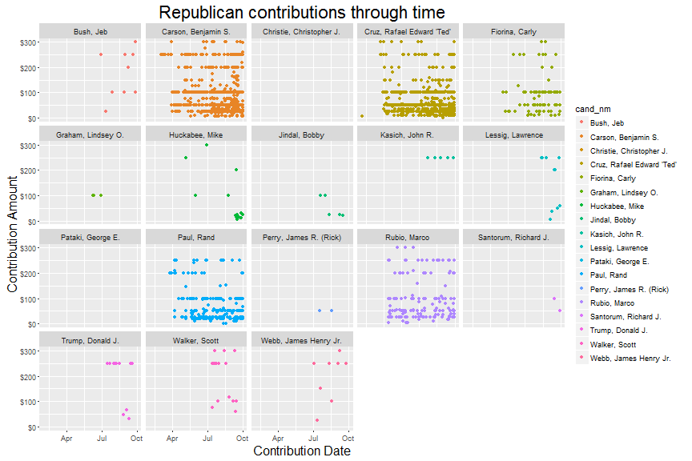

Wow, lots of chatter in the data for Carson and Cruz.  
Also several with nothing in this spot, should probably take them out.

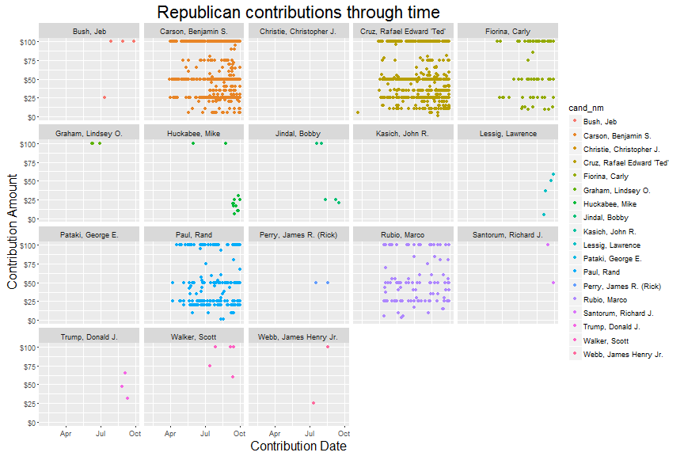

## All candidates over time

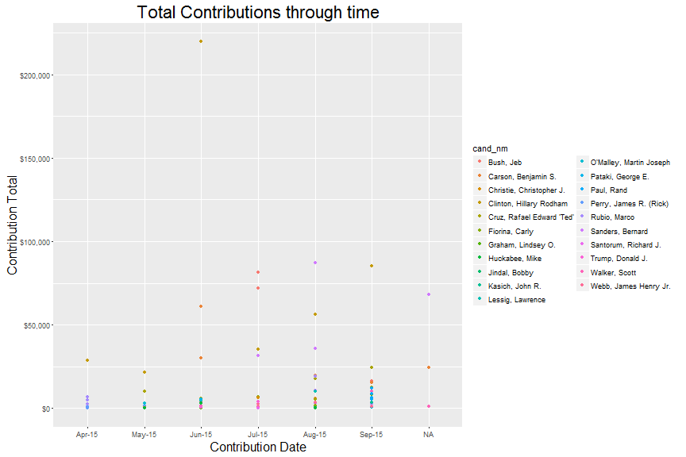

Lots of noise at the bottom, time to look at less then $500 a day, also need to fix the dates on the y axis.

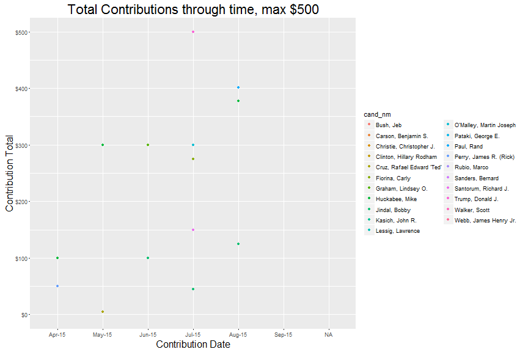

What if we only look at the top candidates

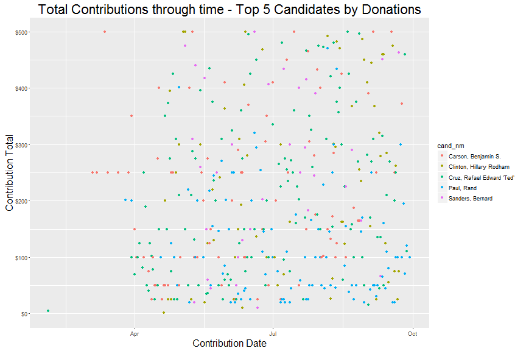

## Political Party Factored by County

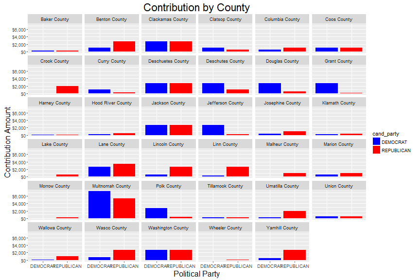

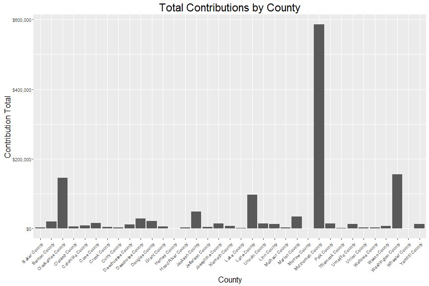

```
## Source: local data frame [3 x 5]
##
##              county county_mean county_median county_sum     n
##              (fctr)       (dbl)         (dbl)      (dbl) (int)
## 1  Multnomah County    377.6686           100   586141.7  1552
## 2 Washington County    179.5129            50   155099.2   864
## 3  Clackamas County    229.5872            50   145558.3   634
```

# Final Evaluation Graphs

These charts are the final charts showing more detailed analysis

[figure not shown]

[figure not shown]

[figure not shown]

## Reflection

Oregon has long been a Blue State when it comes to the Presidential elections, so finding that the Democratic Candidates had a greater support base was not unexpected. I was also unsurprised to see that the top counties and zip codes are those that make up and surround the Portland area as it is the most population dense. It was interesting to see that even in these urban areas there was still a strong showing for Republican candidates, which I found to be unexpected. Overall the information presented matched expected results and was an interesting peak into the financial side of the election.

One of the challenges with this data set was manipulating the date information to be able to group them and to show them in the plots in the correct order. This required learning some new techniques that were not covered within the online classes for the project.

I think an interesting further analysis would be to look within the top zip codes within the 4 digit extensions and determine if there are red or blue pockets that are clearly defined. You could carry that information over to all the zip codes and do a breakdown of the red vs blue contributions per zip code. One could use the ratio of democrat versus republican contributions to set different shades of color from blue through shades of purple to red.